# Lab 4 – Image Filtering

**Import the necessary libraries for Lab 4:**

```python
%matplotlib inline
import numpy as np
import cv2
import matplotlib.pylab as plt
from skimage import transform,io,color,img_as_ubyte
from scipy import signal,ndimage
```

Load the image of your choice as **grayscale** image:

```
shape= (352, 840)
```

[figure not shown]

```python
img=plt.imread("frozen2.jpg")
img=color.rgb2gray(img)
img=img_as_ubyte(img)

print("shape=",np.shape(img))
plt.imshow(img, cmap = 'gray')
```

#### **Follow the instructions in each section:**

### Part 1 – DFT Properties

Use the supplied function *dft_demo()* :

```python
def dft_demo():
    # Demonstration of effect of the "fftshift" command on the amplitude and on the spectrum of the image.
    #-----------------------------------------------------------------------------------------------------#
    N1 = 100; N2=100; M1=20; M2=20
    A = np.zeros([N1,N2])
    A[(N1-M1)//2:(N1+M1)//2,(N2-M2)//2:(N2+M2)//2]=255
    B = np.fft.fft2(A)
    log_magnitude_B= 20*np.log(np.abs(B)+1) # add 1 - in order to prevent log(0)
    B_fftshift=np.fft.fftshift(B)
    log_magnitude_B_fftshift= 20*np.log(np.abs(B_fftshift)+1)

    fig, axes = plt.subplots(nrows=1, ncols=3, figsize=(8, 8))
    ax = axes.ravel()
    ax[0].imshow(A, cmap='gray')
    ax[0].set_title('The original image'), ax[0].axis('off')
    ax[1].imshow(log_magnitude_B, cmap='gray')
    ax[1].set_title('|DFT(a)| [dB]')
    ax[2].imshow(log_magnitude_B_fftshift, cmap='gray')
    ax[2].set_title('|DFT(a)| [dB] + fftshift')
    plt.tight_layout()

    # Linearity - 3 demonstrations (two horizontal boxes, two vertical boxes and four boxes)
    #----------------------------------------------------------------------------------------------------#
    # Two horizontal boxes
    delta=40
    A2_hor=np.zeros([N1,N2])
    A2_hor[(N1-M1)//2:(N1+M1)//2,(N2-delta-M2)//2:(N2-delta+M2)//2]=255
    A2_hor[(N1-M1)//2:(N1+M1)//2,(N2+delta-M2)//2:(N2+delta+M2)//2]=255
    B2_hor=np.fft.fft2(A2_hor)
    B2_hor_magnitude = 20*np.log(np.abs(np.fft.fftshift(B2_hor))+1)

    fig, axes = plt.subplots(nrows=2, ncols=2, figsize=(6, 6))
    ax = axes.ravel()
    ax[0].imshow(A, cmap='gray')
    ax[0].set_title('One box'), ax[0].axis('off')
    ax[1].imshow(log_magnitude_B_fftshift, cmap='gray')
    ax[1].set_title('|DFT{One box}| [dB]')
    ax[2].imshow(A2_hor, cmap='gray')
    ax[2].set_title('Two horizontal boxes'), ax[2].axis('off')
    ax[3].imshow(B2_hor_magnitude, cmap='gray')
    ax[3].set_title('|DFT{Two horizontal boxes}|[dB]')
    plt.tight_layout()

    # Two vertical boxes
    A2_ver=np.zeros([N1,N2])
    A2_ver[(N1-delta-M1)//2:(N1-delta+M1)//2,(N2-M2)//2:(N2+M2)//2]=255
    A2_ver[(N1+delta-M1)//2:(N1+delta+M1)//2,(N2-M2)//2:(N2+M2)//2]=255
    B2_ver=np.fft.fft2(A2_ver)
    B2_ver_magnitude = 20*np.log(np.abs(np.fft.fftshift(B2_ver))+1)

    fig, axes = plt.subplots(nrows=1, ncols=2, figsize=(6, 6))
    ax = axes.ravel()
    ax[0].imshow(A2_ver, cmap='gray')
    ax[0].set_title('Two vertical boxes'), ax[0].axis('off')
    ax[1].imshow(B2_ver_magnitude, cmap='gray')
    ax[1].set_title('|DFT{Two vertical boxes}|[dB]')
    plt.tight_layout()

    # Four boxes
    A4=np.zeros([N1,N2])
    A4[(N1-delta-M1)//2:(N1-delta+M1)//2,(N2-delta-M2)//2:(N2-delta+M2)//2]=255
    A4[(N1+delta-M1)//2:(N1+delta+M1)//2,(N2-delta-M2)//2:(N2-delta+M2)//2]=255
    A4[(N1-delta-M1)//2:(N1-delta+M1)//2,(N2+delta-M2)//2:(N2+delta+M2)//2]=255
    A4[(N1+delta-M1)//2:(N1+delta+M1)//2,(N2+delta-M2)//2:(N2+delta+M2)//2]=255
    B4=np.fft.fft2(A4)
    B4_magnitude = 20*np.log(np.abs(np.fft.fftshift(B4))+1)

    fig, axes = plt.subplots(nrows=1, ncols=2, figsize=(6, 6))
    ax = axes.ravel()
    ax[0].imshow(A4, cmap='gray')
    ax[0].set_title('Four boxes'), ax[0].axis('off')
    ax[1].imshow(B4_magnitude, cmap='gray')
    ax[1].set_title('|DFT{Four boxes}|[dB]')
    plt.tight_layout()

    # Scaling (reduction and enlargement)
    #----------------------------------------------------------------------------------------------------#
    # Reduction
    M1_small=10; M2_small=10
    A_small = np.zeros([N1,N2])
    A_small[(N1-M1_small)//2:(N1+M1_small)//2,(N2-M2_small)//2:(N2+M2_small)//2]=255
    B_small = np.fft.fft2(A_small)
    log_magnitude_B_small= 20*np.log(np.abs(np.fft.fftshift(B_small))+1)

    # Enlargement
    M1_large=40; M2_large=40
    A_large = np.zeros([N1,N2])
    A_large[(N1-M1_large)//2:(N1+M1_large)//2,(N2-M2_large)//2:(N2+M2_large)//2]=255
    B_large = np.fft.fft2(A_large)
    log_magnitude_B_large= 20*np.log(np.abs(np.fft.fftshift(B_large))+1)

    fig, axes = plt.subplots(nrows=2, ncols=2, figsize=(6, 6))
    ax = axes.ravel()
    ax[0].imshow(A_small, cmap='gray')
    ax[0].set_title('Reduced image'), ax[0].axis('off')
    ax[1].imshow(log_magnitude_B_small, cmap='gray')
    ax[1].set_title('|DFT{Reduced A}| [dB]')
    ax[2].imshow(A_large, cmap='gray')
    ax[2].set_title('Enlarged image'), ax[2].axis('off')
    ax[3].imshow(log_magnitude_B_large, cmap='gray')
    ax[3].set_title('|DFT{Enlarged A}|[dB]')
    plt.tight_layout()

    # Rotation
    #----------------------------------------------------------------------------------------------------#
    theta = 45 #in degrees
    A_rotate = transform.rotate(A, angle=theta)
    B_rotate = np.fft.fft2(A_rotate)
    log_magnitude_B_rotate= 20*np.log(np.abs(np.fft.fftshift(B_rotate))+1)

    fig, axes = plt.subplots(nrows=1, ncols=2, figsize=(6, 6))
    ax = axes.ravel()
    ax[0].imshow(A_rotate, cmap='gray')
    ax[0].set_title('Rotated image'), ax[0].axis('off')
    ax[1].imshow(log_magnitude_B_rotate, cmap='gray')
    ax[1].set_title('|DFT{Rotated A}|[dB]')
    plt.tight_layout()
```

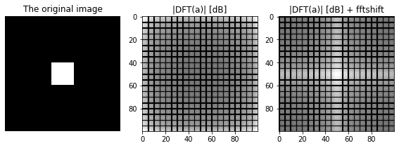

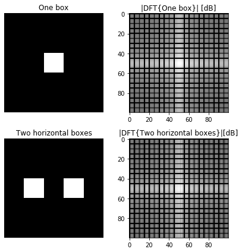

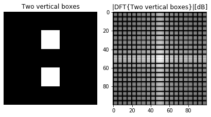

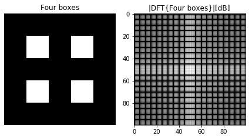

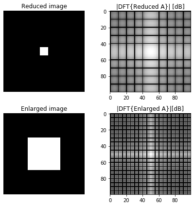

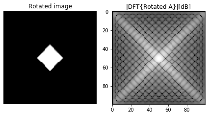

```python
dft_demo()
```

- Observe the following properties and demonstrations from the *dft_demo()*:
  - fftshift command.
  - Linearity.
  - Scaling.
  - Rotation.

Add a short explanation of each of the observations above.

- Represent the DFT transform of the image of your choice.  
  Show the 3 following plots: Your image, the regular transformation without *fftshift* and transformation with the *fftshift* function.

[figure not shown]

```python
    A = np.zeros([np.shape(img)[0],np.shape(img)[1]])
    A=A+img
    B = np.fft.fft2(A)
    log_magnitude_B= 20*np.log(np.abs(B)+1) # add 1 - in order to prevent log(0)
    B_fftshift=np.fft.fftshift(B)
    log_magnitude_B_fftshift= 20*np.log(np.abs(B_fftshift)+1)

    fig, axes = plt.subplots(nrows=1, ncols=3, figsize=(8, 8))
    ax = axes.ravel()
    ax[0].imshow(A, cmap='gray')
    ax[0].set_title('The original image'), ax[0].axis('off')
    ax[1].imshow(log_magnitude_B, cmap='gray')
    ax[1].set_title('|DFT(a)| [dB]')
    ax[2].imshow(log_magnitude_B_fftshift, cmap='gray')
    ax[2].set_title('|DFT(a)| [dB] + fftshift')
    plt.tight_layout()
```

- Test the following properties with your image:
  - Scaling: factors - **½ and 2**
  - Rotation: by **30 and 45 degrees**

    **Note**: for your image the scaling property should be implemented differently than in the demo (you can use the function *transform.rescale*). Also, use zero padding for your image presentation.

[figure not shown]

[figure not shown]

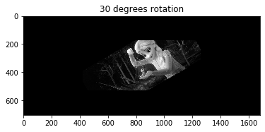

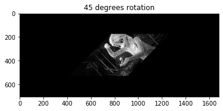

```python
A = np.zeros([2*np.shape(img)[0],2*np.shape(img)[1]])
A_half=transform.rescale(img,0.5,order=0)

A[(np.shape(A)[0]-np.shape(A_half)[0])//2:(np.shape(A)[0]+np.shape(A_half)[0])//2,
  (np.shape(A)[1]-np.shape(A_half)[1])//2:(np.shape(A)[1]+np.shape(A_half)[1])//2]=A_half
plt.figure()
plt.imshow(A, cmap='gray')
plt.title('Half')

B = np.zeros([2*np.shape(img)[0],2*np.shape(img)[1]])
A_twice=transform.rescale(img,2,order=0)
B[(np.shape(B)[0]-np.shape(A_twice)[0])//2:(np.shape(B)[0]+np.shape(A_twice)[0])//2,
  (np.shape(B)[1]-np.shape(A_twice)[1])//2:(np.shape(B)[1]+np.shape(A_twice)[1])//2]=A_twice
plt.figure()
plt.imshow(B, cmap='gray')
plt.title('factor 2')

A30=transform.rotate(img,30,order=0)
C = np.zeros([2*np.shape(img)[0],2*np.shape(img)[1]])
C[(np.shape(C)[0]-np.shape(A30)[0])//2:(np.shape(C)[0]+np.shape(A30)[0])//2,
  (np.shape(C)[1]-np.shape(A30)[1])//2:(np.shape(C)[1]+np.shape(A30)[1])//2]=A30
plt.figure()
plt.imshow(C, cmap='gray')
plt.title('30 degrees rotation')

A45=transform.rotate(img,45,order=0)
D = np.zeros([2*np.shape(img)[0],2*np.shape(img)[1]])
D[(np.shape(D)[0]-np.shape(A45)[0])//2:(np.shape(D)[0]+np.shape(A45)[0])//2,
  (np.shape(D)[1]-np.shape(A45)[1])//2:(np.shape(D)[1]+np.shape(A45)[1])//2]=A45

plt.figure()
plt.imshow(D, cmap='gray')
plt.title('45 degrees rotation')
```

- Use the supplied function to exchange between the magnitude and phase of two images of your choice.  
  **Note**: both of the images needed to be with the same shape, resize or crop one of the images if it is necessary.

```python
# Exchange between magnitude and phase
def mag_phas_exchange(img1,img2):
    img1_spectrum = np.fft.fft2(img1)
    img1_magnitude = np.abs(img1_spectrum)
    img1_phase = np.angle(img1_spectrum)
    img2_spectrum = np.fft.fft2(img2)
    img2_magnitude = np.abs(img2_spectrum)
    img2_phase = np.angle(img2_spectrum)

    # Magnitude of img1, phase of img2
    img1_img2_spectrum = img1_magnitude * np.exp(1j*img2_phase)
    img1_img2 = np.abs(np.fft.ifft2(img1_img2_spectrum))

    # Magnitude of img2, phase of img1
    img2_img1_spectrum = img2_magnitude * np.exp(1j*img1_phase)
    img2_img1 = np.abs(np.fft.ifft2(img2_img1_spectrum))

    fig, axes = plt.subplots(nrows=2, ncols=2, figsize=(7, 7))
    ax = axes.ravel()
    ax[0].imshow(img1, cmap='gray')
    ax[0].set_title('Img1'), ax[0].axis('off')
    ax[1].imshow(img2, cmap='gray')
    ax[1].set_title('Img2'), ax[1].axis('off')
    ax[2].imshow(img2_img1, cmap='gray')
    ax[2].set_title('Magnitude of img2, phase of img1'), ax[2].axis('off')
    ax[3].imshow(img1_img2, cmap='gray')
    ax[3].set_title('Magnitude of img1, phase of img2'), ax[3].axis('off')
    plt.tight_layout()
```

[figure not shown]

```python
img2=plt.imread("eat_your_vegetables.jpg")
img2=color.rgb2gray(img2)
img2=img_as_ubyte(img2)

AA = np.zeros([2*np.shape(img)[0],2*np.shape(img)[1]])
AA[(np.shape(AA)[0]-np.shape(img)[0])//2:(np.shape(AA)[0]+np.shape(img)[0])//2,
  (np.shape(AA)[1]-np.shape(img)[1])//2:(np.shape(AA)[1]+np.shape(img)[1])//2]=img

BB = np.zeros([2*np.shape(img)[0],2*np.shape(img)[1]])
BB[(np.shape(BB)[0]-np.shape(img2)[0])//2:(np.shape(BB)[0]+np.shape(img2)[0])//2,
  (np.shape(BB)[1]-np.shape(img2)[1])//2:(np.shape(BB)[1]+np.shape(img2)[1])//2]=img2

mag_phas_exchange(AA,BB)
```

As we learned in class, the phase of the image is more dominent than the Magnitude. That is why for instance we see image that looks like img1 when using img1's phase.

### Part 2 – Convolution

Use the supplied function *conv_demo*.  
The function demonstrate the computation of convolution using 2 methods:

1. direct method (in spatial domain).
2. indirect method (in frequency domain).

```python
def conv_demo():
    #----The computation of convolution by direct method (in spatial domain)
    N1 = 100; N2=100; M1=30; M2=30
    A = np.zeros([N1,N2])
    A[(N1-M1)//2:(N1+M1)//2,(N2-M2)//2:(N2+M2)//2]=255
    blur_kernel = (1.0/36)*np.ones((6,6))
    img_blurred_using_spatial = signal.convolve2d(A,blur_kernel)
    fig, axes = plt.subplots(nrows=1, ncols=2, figsize=(7, 7))
    ax = axes.ravel()
    ax[0].imshow(A, cmap='gray')
    ax[0].set_title('The original image'), ax[0].axis('off')
    ax[1].imshow(img_blurred_using_spatial, cmap='gray')
    ax[1].set_title('The blurred image'), ax[1].axis('off')
    plt.tight_layout()

    #---The computation of convolution by indirect method (in frequency domain)
    N = A.shape[0]+blur_kernel.shape[0]
    M = A.shape[1]+blur_kernel.shape[1]
    img_spectrum=np.fft.fftshift(np.fft.fft2(A,s=(N,M)))
    blur_kernel_spectrum=np.fft.fftshift(np.fft.fft2(blur_kernel,s=(N,M)))
    img_blurred_spectrum=img_spectrum*blur_kernel_spectrum
    img_blurred_using_dft=np.abs(np.fft.ifft2(img_blurred_spectrum))



    fig, axes = plt.subplots(nrows=1, ncols=1, figsize=(3, 3))
    axes.imshow(A, cmap='gray')
    axes.set_title('The original image'), axes.axis('off')

    fig, axes = plt.subplots(nrows=1, ncols=3, figsize=(8, 8))
    ax = axes.ravel()
    ax[0].imshow(20*np.log(np.abs(img_spectrum)+1), cmap='gray')
    ax[0].set_title('Spectrum of orig. image'), ax[0].axis('off')
    ax[1].imshow(20*np.log(np.abs(blur_kernel_spectrum)+1), cmap='gray')
    ax[1].set_title('Spectrum of blur. kernel'), ax[1].axis('off')
    ax[2].imshow(20*np.log(np.abs(img_blurred_spectrum)+1), cmap='gray')
    ax[2].set_title('Spectrum of blur. image'), ax[2].axis('off')

    fig, axes = plt.subplots(nrows=1, ncols=1, figsize=(3, 3))
    axes.imshow(img_blurred_using_dft, cmap='gray')
    axes.set_title('Blurred image'), axes.axis('off')
```

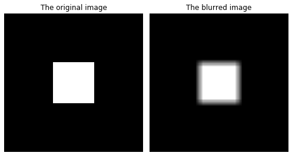

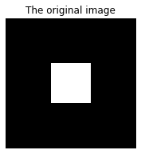

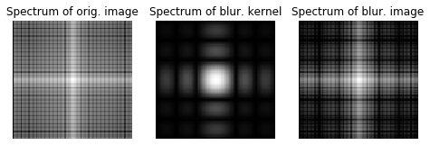

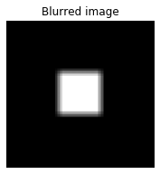

```python
conv_demo()
```

- Observe the results of convolution with those two methods (in spatial domain and in frequency domain).

The convolution in space domain is similar to multiplication in the frequency domain as we can see in the demo. We assume that the the minor differences exist because the FFT/IFFT algorithm has some aliasing using its LPF filter (the signal in space is a rectengle which is a sinc in frequency domain, when applying LPF filter on a sinc some high frequencies are removed).

- Test the implementation of convolution with those two methods on image of your choice.  
  Observe your results.

```
(Text(0.5, 1.0, 'Blurred image'), (-0.5, 845.5, 357.5, -0.5))
```

[figure not shown]

[figure not shown]

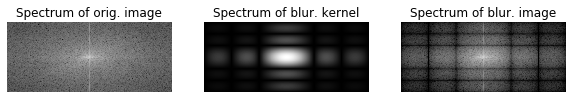

[figure not shown]

```python
#----The computation of convolution by direct method (in spatial domain)
img3=plt.imread("frozen2.jpg")
img3=color.rgb2gray(img3)
img3=img_as_ubyte(img3)
blur_kernel = (1.0/36)*np.ones((6,6))
img_blurred_using_spatial = signal.convolve2d(img3,blur_kernel)
fig, axes = plt.subplots(nrows=1, ncols=2, figsize=(10, 10))
ax = axes.ravel()
ax[0].imshow(img3, cmap='gray')
ax[0].set_title('The original image'), ax[0].axis('off')
ax[1].imshow(img_blurred_using_spatial, cmap='gray')
ax[1].set_title('The blurred image'), ax[1].axis('off')
plt.tight_layout()

#---The computation of convolution by indirect method (in frequency domain)
N = img3.shape[0]+blur_kernel.shape[0]
M = img3.shape[1]+blur_kernel.shape[1]
img_spectrum=np.fft.fftshift(np.fft.fft2(img3,s=(N,M)))
blur_kernel_spectrum=np.fft.fftshift(np.fft.fft2(blur_kernel,s=(N,M)))
img_blurred_spectrum=img_spectrum*blur_kernel_spectrum
img_blurred_using_dft=np.abs(np.fft.ifft2(img_blurred_spectrum))



fig, axes = plt.subplots(nrows=1, ncols=1, figsize=(7, 7))
axes.imshow(img3, cmap='gray')
axes.set_title('The original image'), axes.axis('off')

fig, axes = plt.subplots(nrows=1, ncols=3, figsize=(10, 10))
ax = axes.ravel()
ax[0].imshow(20*np.log(np.abs(img_spectrum)+1), cmap='gray')
ax[0].set_title('Spectrum of orig. image'), ax[0].axis('off')
ax[1].imshow(20*np.log(np.abs(blur_kernel_spectrum)+1), cmap='gray')
ax[1].set_title('Spectrum of blur. kernel'), ax[1].axis('off')
ax[2].imshow(20*np.log(np.abs(img_blurred_spectrum)+1), cmap='gray')
ax[2].set_title('Spectrum of blur. image'), ax[2].axis('off')

fig, axes = plt.subplots(nrows=1, ncols=1, figsize=(10,10))
axes.imshow(img_blurred_using_dft, cmap='gray')
axes.set_title('Blurred image'), axes.axis('off')
```

The convolution in space domain is equivalent to multiplication in the frequency domain as we can see in the demo. as we can see we got blured princess by convoluting in spatial domain and by multiplication in frequancy domain with bluring kernel

- Implement convolution with median filter using python’s *ndimage.median_filter* and uniform filter by using *ndimage.uniform_filter*.  
  Explain the difference between your results.

[figure not shown]

[figure not shown]

[figure not shown]

```python
img4=plt.imread("frozen2.jpg")
img4=color.rgb2gray(img4)
img4=img_as_ubyte(img4)

plt.figure(1)
plt.imshow(img4, cmap='gray')
plt.title('Orginal elsa')

img4_median_filtered = ndimage.median_filter(img4,size=15)

plt.figure(2)
plt.imshow(img4_median_filtered, cmap='gray')
plt.title('Elsa with median filter')

img4_uniform_filtered = ndimage.uniform_filter(img4,size=15)

plt.figure(3)
plt.imshow(img4_uniform_filtered, cmap='gray')
plt.title('Elsa with uniform filter')
```

As can see using both filters gives a blurred images, but of a different type. the median filter damages the edges less compared to the uniform fiter (median - sharper, uniform - more blurred). This goes along with the theory discussed in class.

- Observe the Fourier Transform of the filters in the given demo.  
  Determine which filter are high pass filters and which are low pass filters.

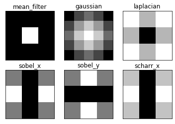

```python
# simple averaging filter without scaling parameter
mean_filter = np.ones((3,3))

# creating a guassian filter
x = cv2.getGaussianKernel(5,0.5)
gaussian = x*x.T

# different edge detecting filters
# scharr in x-direction
scharr = np.array([[-3, 0, 3],
                   [-10,0,10],
                   [-3, 0, 3]])
# sobel in x direction
sobel_x= np.array([[-1, 0, 1],
                   [-2, 0, 2],
                   [-1, 0, 1]])
# sobel in y direction
sobel_y= np.array([[-1,-2,-1],
                   [0, 0, 0],
                   [1, 2, 1]])
# laplacian
laplacian=np.array([[0, 1, 0],
                    [1,-4, 1],
                    [0, 1, 0]])

filters = [mean_filter, gaussian, laplacian, sobel_x, sobel_y, scharr]
filter_name = ['mean_filter', 'gaussian','laplacian', 'sobel_x', \
                'sobel_y', 'scharr_x']
fft_filters = [np.fft.fft2(x) for x in filters]
fft_shift = [np.fft.fftshift(y) for y in fft_filters]
mag_spectrum = [np.log(np.abs(z)+1) for z in fft_shift]

for i in range(6):
    plt.subplot(2,3,i+1),plt.imshow(mag_spectrum[i],cmap = 'gray')
    plt.title(filter_name[i]), plt.xticks([]), plt.yticks([])
plt.show()
```

Let's remember that low frequncies are in the middle, and high frequncies are far from middle (on the edges). mean filter - LPF with sharp edgeds gaussian - LPF with curved edges laplacian - HPF, high frequncies in edges. sobel_x - HPF, with x orientation sobel_y - HPF, with y orientation scharr_X - HPF, with x orientation

**Bonus**: Implement the following filters with the image of your choice.

[figure not shown]

[figure not shown]

[figure not shown]

[figure not shown]

[figure not shown]

[figure not shown]

```python
img_blurred_using_spatial1 = signal.convolve2d(img4,mean_filter)
plt.figure()
plt.imshow(img_blurred_using_spatial1, cmap='gray')
plt.title('Elsa with mean filter')

img_blurred_using_spatial2 = signal.convolve2d(img4,gaussian)
plt.figure()
plt.imshow(img_blurred_using_spatial2, cmap='gray')
plt.title('Elsa with gaussian filter')
img_blurred_using_spatial3 = signal.convolve2d(img4,scharr)
plt.figure()
plt.imshow(img_blurred_using_spatial3, cmap='gray')
plt.title('Elsa with schar filter')
img_blurred_using_spatial4 = signal.convolve2d(img4,sobel_x)
plt.figure()
plt.imshow(img_blurred_using_spatial4, cmap='gray')
plt.title('Elsa with sobel x filter')
img_blurred_using_spatial5 = signal.convolve2d(img4,sobel_y)
plt.figure()
plt.imshow(img_blurred_using_spatial5, cmap='gray')
plt.title('Elsa with sobel y filter')
img_blurred_using_spatial6 = signal.convolve2d(img4,laplacian)
plt.figure()
plt.imshow(img_blurred_using_spatial6, cmap='gray')
plt.title('Elsa with laplacian filter')
```